# Лабораторна робота 3

**Тема:** Геометричні перетворення зображення

**Мета:** знайомство з методами геометричних перетворень бібліотеки OpenCV у середовищі Anaconda із застосуванням Jupyter Notebook засобами мови програмування Python.

## Завдання для самостійної роботи

1. Завантажити Anaconda та активувати віртуальне середовище з ім’ям _OpenCV, створене у лабораторній роботі №1.

[figure not shown]

2. Створити Notebook-документ за допомогою Jupyter Notebook.

[figure not shown]

3. Імпортувати RGB-зображення Image з диску. Оцінити його розмір у пікселях N x M та об’єм пам’яті, який він займає на диску.

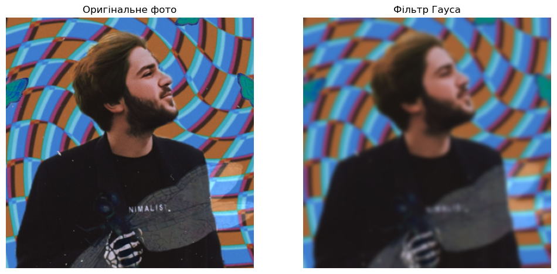

```python
import cv2
import numpy as np
import matplotlib.pyplot as plt

filename = 'src/photo.png'
image = cv2.imread(filename)

if image is None:
    print(f"Помилка: Не вдалося знайти файл {filename}")
else:
    gaussian_blur = cv2.GaussianBlur(image, (15, 15), 0)
    plt.figure(figsize=(12, 6))

    plt.subplot(1, 2, 1)
    if len(image.shape) == 3:
        plt.imshow(cv2.cvtColor(image, cv2.COLOR_BGR2RGB))
    else:
        plt.imshow(image, cmap='gray')
    plt.title("Оригінальне фото")
    plt.axis('off')

    plt.subplot(1, 2, 2)
    if len(gaussian_blur.shape) == 3:
        plt.imshow(cv2.cvtColor(gaussian_blur, cv2.COLOR_BGR2RGB))
    else:
        plt.imshow(gaussian_blur, cmap='gray')
    plt.title("Фільтр Гауса")
    plt.axis('off')
    plt.show()
```

4. Імпортувати RGB-зображення Image у напівтоновому форматі. Оцінити його розмір у пікселях та об’єм пам’яті, який він займає на диску. Порівняти результати з попередніми результатами. Пояснити результати.

```
ЗАВДАННЯ 3 RGB зображення
Розмір (NxM):      388 x 383
Кількість каналів: 3
Об'єм на диску:    267570 байт
ЗАВДАННЯ 4 Напівтонове зображення
Розмір (NxM):      388 x 383
Кількість каналів: 1
Об'єм на диску:    72600 байт
ПОРІВНЯННЯ:
Розмір у пікселях:RGB: 388x383 | Gray: 388x383
Результат: Розмір зображення не змінюється.
Об'єм на диску:RGB: 267570 байт| Gray: 72600 байт
Результат: Файл RGB у 3.7 разів більший. Це пояснюється тим, що в RGB для кожного пікселя зберігаються три колірні канали, тоді як напівтонове зображення містить лише один канал.
```

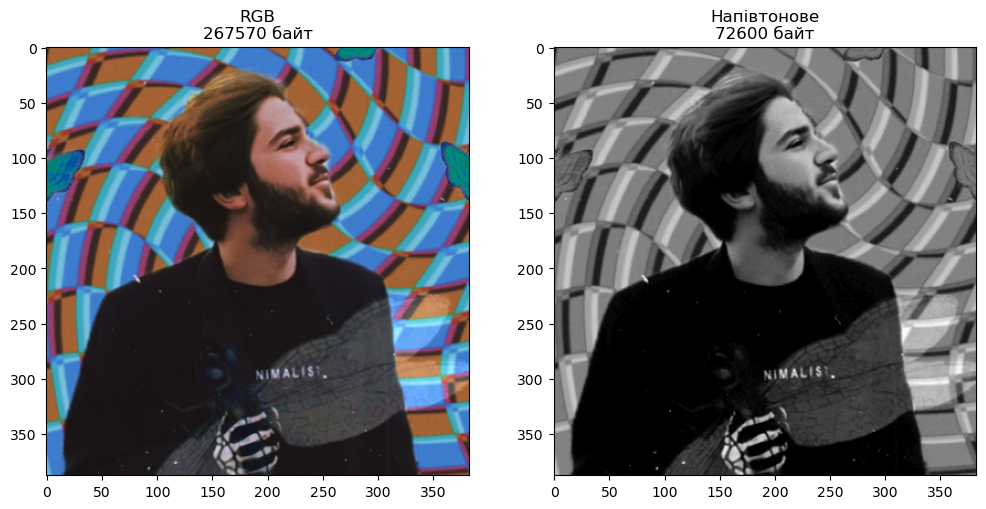

```python
import cv2 as cv
import os
import matplotlib.pyplot as plt
import numpy as np

image_path = 'src/photo.png'
image_bgr = cv.imread(image_path)
image_gray = cv.imread(image_path, cv.IMREAD_GRAYSCALE)

if image_bgr is None:
    print(f"Помилка:{image_path}")
else:
    print(f"ЗАВДАННЯ 3 RGB зображення")
    height_rgb, width_rgb, channels_rgb = image_bgr.shape
    file_size_rgb = os.path.getsize(image_path)
    print(f"Розмір (NxM):      {height_rgb} x {width_rgb}")
    print(f"Кількість каналів: {channels_rgb}")
    print(f"Об'єм на диску:    {file_size_rgb} байт")
    print(f"ЗАВДАННЯ 4 Напівтонове зображення")
    gray_path = 'src/photo_gray.png'
    cv.imwrite(gray_path, image_gray)
    height_gray, width_gray = image_gray.shape
    file_size_gray = os.path.getsize(gray_path)
    print(f"Розмір (NxM):      {height_gray} x {width_gray}")
    print(f"Кількість каналів: 1")
    print(f"Об'єм на диску:    {file_size_gray} байт")
    #ПОРІВНЯННЯ
    print(f"ПОРІВНЯННЯ:")
    print(f"Розмір у пікселях:RGB: {height_rgb}x{width_rgb} | Gray: {height_gray}x{width_gray}")
    print(f"Результат: Розмір зображення не змінюється.")
    print(f"Об'єм на диску:RGB: {file_size_rgb} байт| Gray: {file_size_gray} байт")
    ratio = file_size_rgb / file_size_gray
    print(f"Результат: Файл RGB у {ratio:.1f} разів більший. Це пояснюється тим, що в RGB для кожного пікселя зберігаються три колірні канали, тоді як напівтонове зображення містить лише один канал.")
    plt.figure(figsize=(12, 6))

    plt.subplot(1, 2, 1)
    plt.imshow(cv.cvtColor(image_bgr, cv.COLOR_BGR2RGB)); plt.title(f'RGB\n{file_size_rgb} байт'); plt.subplot(1, 2, 2)
    plt.imshow(image_gray, cmap='gray'); plt.title(f'Напівтонове\n{file_size_gray} байт'); plt.show()
```

5. Зменшити початкове RGB-зображення Image у n разів, візуалізувати його, перевіривши результат масштабування, та експортувати його на диск. Чи змінився об’єм пам’яті, який він займає на диску? Обгрунтувати отриманий результат.

```
Результати:
Оригінал (N x M): 388 x 383
Об'єм (оригінал): 267570 байт (261.3 KB)

Зменшено у 2 рази:
Новий розмір:194 x 191

Новий об'єм:64453 байт (62.9 KB)

Результат
Так, об'єм пам'яті зменшився на 203117 байт (у 4.2 разів).
Пояснення: для n=2 кількість пікселів зменшилася у 4 рази.
Менша кількість пікселів означає менший обсяг даних для зберігання, тому розмір файлу зменшився.
```

[figure not shown]

```python
import cv2 as cv
import os
import matplotlib.pyplot as plt
import math

image_path = 'src/photo.png'
n = 2
image_rgb = cv.imread(image_path)

if image_rgb is None:
    print(f"Не удалось открыть изображение: {image_path}")
else:
    height_N, width_M, _ = image_rgb.shape
    file_size_original = os.path.getsize(image_path)

    print(f"Результати:")
    print(f"Оригінал (N x M): {height_N} x {width_M}")
    print(f"Об'єм (оригінал): {file_size_original} байт ({file_size_original/1024:.1f} KB)\n")

    new_width = math.floor(width_M / n)
    new_height = math.floor(height_N / n)
    new_dim = (new_width, new_height)
    image_resized = cv.resize(image_rgb, new_dim, interpolation=cv.INTER_AREA)

    print(f"Зменшено у {n} рази:")
    print(f"Новий розмір:{new_height} x {new_width}\n")

    resized_path = 'src/photo_resized.png'
    # Сохраняем с сжатием (для PNG уровень сжатия от 0 до 9)
    cv.imwrite(resized_path, image_resized, [cv.IMWRITE_PNG_COMPRESSION, 9])

    file_size_resized = os.path.getsize(resized_path)
    print(f"Новий об'єм:{file_size_resized} байт ({file_size_resized/1024:.1f} KB)\n")

    print(f"Результат")
    if file_size_resized < file_size_original:
        diff = file_size_original - file_size_resized
        ratio = file_size_original / file_size_resized
        print(f"Так, об'єм пам'яті зменшився на {diff} байт (у {ratio:.1f} разів).")
        print("Пояснення: для n=2 кількість пікселів зменшилася у 4 рази.")
        print("Менша кількість пікселів означає менший обсяг даних для зберігання, тому розмір файлу зменшився.")
    else:
        print("Ні, обсяг пам’яті не зменшився або навіть зріс.")
    plt.figure(figsize=(12, 6))
    plt.subplot(1, 2, 1)
    plt.imshow(cv.cvtColor(image_rgb, cv.COLOR_BGR2RGB))
    plt.title(f'Оригінал\n{height_N}x{width_M}')
    plt.subplot(1, 2, 2)
    plt.imshow(cv.cvtColor(image_resized, cv.COLOR_BGR2RGB))
    plt.title(f'Зменшене\n{new_height}x{new_width}')
    plt.show()
```

6. Написати функцію, яка буде виконувати пропорційне зменшення початкового зображення розміром N x M пікселей відповідно до вимоги, щоби зменешене зображення мало ширину K пікселей.

```
Результати Завдання 6
ширина K: 100 пікселів
Оригінал (h x w): 388 x 383
Результат (h x w): 101 x 100
```

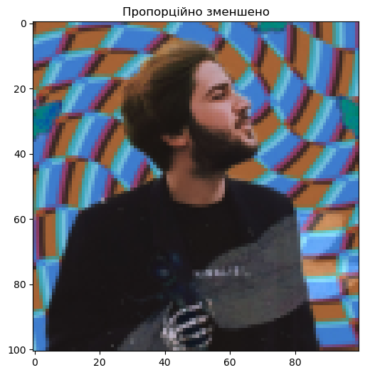

```python
import cv2 as cv
import matplotlib.pyplot as plt

def resize_proportional(image, target_width):
    (h, w) = image.shape[:2]
    ratio = target_width / float(w)
    target_height = int(h * ratio)
    new_dimensions = (target_width, target_height)
    resized_img = cv.resize(image, new_dimensions, interpolation=cv.INTER_AREA)
    return resized_img

image_path = 'src/photo.png'
K = 100

image_bgr = cv.imread(image_path)

if image_bgr is None:
    print(f"Помилка: Не вдалося знайти файл {image_path}")
else:
    image_resized_k = resize_proportional(image_bgr, K)

    print(f"Результати Завдання 6")
    print(f"ширина K: {K} пікселів")
    print(f"Оригінал (h x w): {image_bgr.shape[0]} x {image_bgr.shape[1]}")
    print(f"Результат (h x w): {image_resized_k.shape[0]} x {image_resized_k.shape[1]}")

    plt.figure(figsize=(6, 6))
    plt.imshow(cv.cvtColor(image_resized_k, cv.COLOR_BGR2RGB))
    plt.title(f'Пропорційно зменшено')
    plt.show()
```

7. Зробити фото розвороту власної залікової книжки з перспективним викривленням на фоні письмового столу. Вирізати зону із заліковкою та виконати афінні та перспективні перетворення за трьома точками точками і візуалізовані. В кожному випадку результати мають бути записані на диск.

```
Розмір зображення: 2560x1920
```

[figure not shown]

```python
import cv2 as cv
import numpy as np
import matplotlib.pyplot as plt

image_path = 'src/Zalikova.jpg'
image = cv.imread(image_path)

if image is None:
    print(f"Помилка {image_path}")
else:
    rows, cols, ch = image.shape
    print(f"Розмір зображення: {cols}x{rows}")
    pts_input_affine = np.float32([
        [415, 340],
        [573, 342],
        [410, 540]
    ])
    pts_output_affine = np.float32([
         [150, 220],
        [450, 210],
        [140, 600]
    ])
    M_affine = cv.getAffineTransform(pts_input_affine, pts_output_affine)
    img_affine = cv.warpAffine(image, M_affine, (cols, rows))
    pts_input_persp = np.float32([
        [700, 400],
        [1200, 400],
        [700, 1100],
        [1200, 1100]
    ])

    width_new, height_new = 300, 400
    pts_output_persp = np.float32([
        [0, 0],
        [width_new, 0],
        [0, height_new],
        [width_new, height_new]
    ])

    M_persp = cv.getPerspectiveTransform(pts_input_persp, pts_output_persp)
    img_perspective = cv.warpPerspective(image, M_persp, (width_new, height_new))

    plt.figure(figsize=(12, 6))
    plt.subplot(1, 3, 1)
    plt.imshow(cv.cvtColor(image, cv.COLOR_BGR2RGB))
    plt.title("Оригінал")
    plt.grid(True)
    plt.subplot(1, 3, 2)
    plt.imshow(cv.cvtColor(img_affine, cv.COLOR_BGR2RGB))
    plt.title("Афінне")
    plt.subplot(1, 3, 3)
    plt.imshow(cv.cvtColor(img_perspective, cv.COLOR_BGR2RGB))
    plt.title("Перспектива")

    plt.show()
```

# **Контрольні запитання**

1. У чому полягає сенс афінних перетворень?

Суть афінних перетворень полягає у зміні геометрії зображення зі збереженням важливої властивості — паралельності прямих. Це означає, що будь-які лінії, які були паралельними на початковому зображенні, залишаються паралельними й після перетворення. Наприклад, квадрат може бути перетворений на паралелограм, але не на трапецію.

2. Чи є операції трансляції, масштабування і повороту афінними? Відповідь обґрунтувати.

Так, ці операції належать до афінних. Афінне перетворення описується як лінійне перетворення координат із додаванням вектора зсуву.

Трансляція (зсув) полягає в додаванні сталого вектора до координат усіх точок, при цьому паралельність ліній не порушується.

Масштабування здійснюється множенням координат на певний коефіцієнт, що також не впливає на паралельність.

Поворот обертає всі точки зображення навколо заданого центру на фіксований кут, зберігаючи паралельність прямих.

Оскільки в усіх цих випадках паралельні лінії залишаються паралельними, трансляція, масштабування і поворот є афінними перетвореннями.

3. Чи є перспективні перетворення частинним випадком афінних перетворень? Відповідь обґрунтувати.

Ні, перспективні перетворення не є частинним випадком афінних. Навпаки, афінні перетворення можна вважати спрощеним окремим випадком проєктивних (перспективних) перетворень.

Ключова відмінність між ними полягає у збереженні паралельності. Афінні перетворення завжди зберігають паралельність прямих, тоді як перспективні — ні. У перспективному зображенні лінії, які є паралельними в реальності, візуально сходяться в одній точці на горизонті.

Таким чином, перспективні перетворення утворюють більш загальний і складний клас, який дозволяє перетворювати прямокутник у довільний чотирикутник, що неможливо при афінних перетвореннях.